# Hands-on Exercise 8a: Choropleth Mapping with R

Author

Andy Tai

Published

June 16, 2026

Modified

June 16, 2026

## 1 Getting Started

**Install ibraries**

The following R packages will be used:

- Tidyverse:
  - [**readr**](https://readr.tidyverse.org/) for importing delimited text file,
  - [**tidyr**](https://tidyr.tidyverse.org/) for tidying data,
  - [**dplyr**](https://dplyr.tidyverse.org/) for wrangling data and
- [**sf**](https://cran.r-project.org/web/packages/sf/) for handling geospatial data
- tmap for plotting choropleth maps

Code chunk below will be used to check if these packages have been installed and also will load them into the working R environment.

```r
pacman::p_load(sf, tmap, tidyverse)
```

**Import Data**

**(a) Data Overview**

Two data sets will be used to create the choropleth map:

- Master Plan 2014 Subzone Boundary (Web) (i.e. `MP14_SUBZONE_WEB_PL`) in ESRI shapefile format downloaded from [data.gov.sg](https://data.gov.sg/) This geospatial data consists of the geographical boundary of Singapore at the planning subzone level. The data is based on URA Master Plan 2014.
- Singapore Residents by Planning Area / Subzone, Age Group, Sex and Type of Dwelling, June 2011-2020 in csv format (i.e. `respopagesextod2011to2020.csv`). This is an aspatial data file downloaded from [Department of Statistics, Singapore](https://www.singstat.gov.sg/) Although it does not contain any coordinates values, but it’s PA and SZ fields can be used as unique identifiers to geocode to `MP14_SUBZONE_WEB_PL` shapefile.

**(b) Import Geospatial Data**

The code chunk below uses the *st_read()* function of **sf** package to import `MP14_SUBZONE_WEB_PL` shapefile into R as a simple feature data frame called `mpsz`.

```r
mpsz <- st_read(dsn = "data/geospatial",
                layer = "MP14_SUBZONE_WEB_PL")
```

**(c) Import Attribute Data**

```r
popdata <- read_csv("data/aspatial/respopagesextod2011to2020.csv")
```

**Process Data**

Before a thematic map can be prepared, a data table with year 2020 values needs to be prepped. The data table should include the variables PA, SZ, YOUNG, ECONOMY ACTIVE, AGED, TOTAL, DEPENDENCY.

- YOUNG: age group 0 to 4 until age groyup 20 to 24,
- ECONOMY ACTIVE: age group 25-29 until age group 60-64,
- AGED: age group 65 and above,
- TOTAL: all age group, and
- DEPENDENCY: the ratio between young and aged against economy active group

**(a) Data wrangling**

The following data wrangling and transformation functions will be used:

- *pivot_wider()* of **tidyr** package
- *mutate()*, *filter()*, *group_by()* and *select()* of **dplyr** package

```r
popdata2020 <- popdata %>%
  filter(Time == 2020) %>%
  group_by(PA, SZ, AG) %>%
  summarise(`POP` = sum(`Pop`)) %>%
  ungroup() %>%
  pivot_wider(names_from=AG,
              values_from=POP) %>%
  mutate(YOUNG = rowSums(.[3:6])
         +rowSums(.[12])) %>%
mutate(`ECONOMY ACTIVE` = rowSums(.[7:11])+
rowSums(.[13:15]))%>%
mutate(`AGED`=rowSums(.[16:21])) %>%
mutate(`TOTAL`=rowSums(.[3:21])) %>%
mutate(`DEPENDENCY` = (`YOUNG` + `AGED`)
/`ECONOMY ACTIVE`) %>%
  select(`PA`, `SZ`, `YOUNG`,
       `ECONOMY ACTIVE`, `AGED`,
       `TOTAL`, `DEPENDENCY`)
```

**(b) Join attribute & geospatial data**

The values of PA and SZ fields are a mix of upper and lower case. However, the values of SUBZONE_N and PLN_AREA_N are in upper case. Thus, we convert those of PA and SZ to uppercase, before we proceed with the join.

```r
popdata2020 <- popdata2020 %>%
  mutate_at(.vars = vars(PA, SZ),
          .funs = funs(toupper)) %>%
  filter(`ECONOMY ACTIVE` > 0)
```

*left_join()* of **dplyr** is used to join the geographical data and attribute table using planning subzone name e.g. *SUBZONE_N* and *SZ* as the common identifier.

```r
mpsz_pop2020 <- left_join(mpsz, popdata2020,
                          by = c("SUBZONE_N" = "SZ"))
```

**Note**

*left_join()* of **dplyr** package is used with `mpsz` simple feature data frame as the left data table is to ensure that the output will be a simple features data frame.

Save output into rds file

```r
write_rds(mpsz_pop2020, "data/rds/mpszpop2020.rds")
```

## 2 **Choropleth Mapping Geospatial Data Using *tmap***

Two approaches can be used to prepare thematic map using *tmap*:

- Plotting a thematic map quickly by using *qtm()*.
- Plotting highly customisable thematic map by using tmap elements.

**(a) using qtm()**

The easiest and quickest to draw a choropleth map using **tmap** is using *qtm()*. It is concise and provides a good default visualisation in many cases.

The code chunk below will draw a cartographic standard choropleth map.

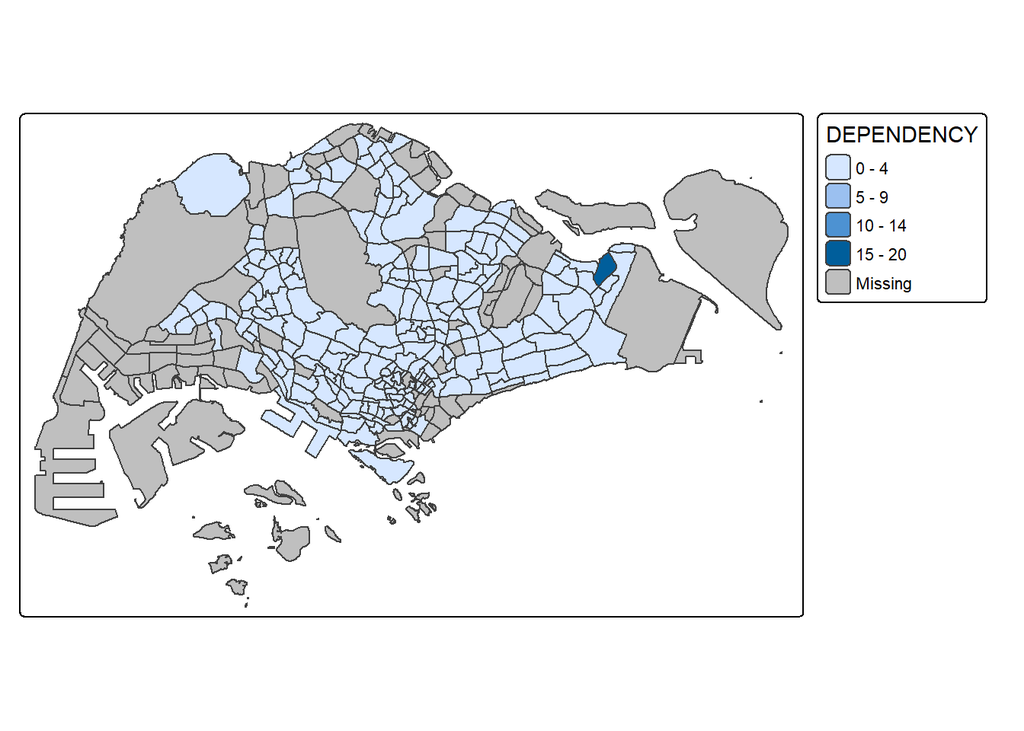

```r
tmap_mode("plot")
qtm(mpsz_pop2020,
    fill = "DEPENDENCY")
```

**Note**

- *tmap_mode()* with “plot” option is used to produce a static map. For interactive mode, “view” option should be used.
- *fill* argument is used to map the attribute (i.e. DEPENDENCY)

**(b) drawing a base map**

The basic building block of **tmap** is *tm_shape()* followed by one or more layer elemments such as *tm_fill()* and *tm_polygons()*.

In the code chunk below, *tm_shape()* is used to define the input data (i.e *mpsz_pop2020*) and *tm_polygons()* is used to draw the planning subzone polygons.

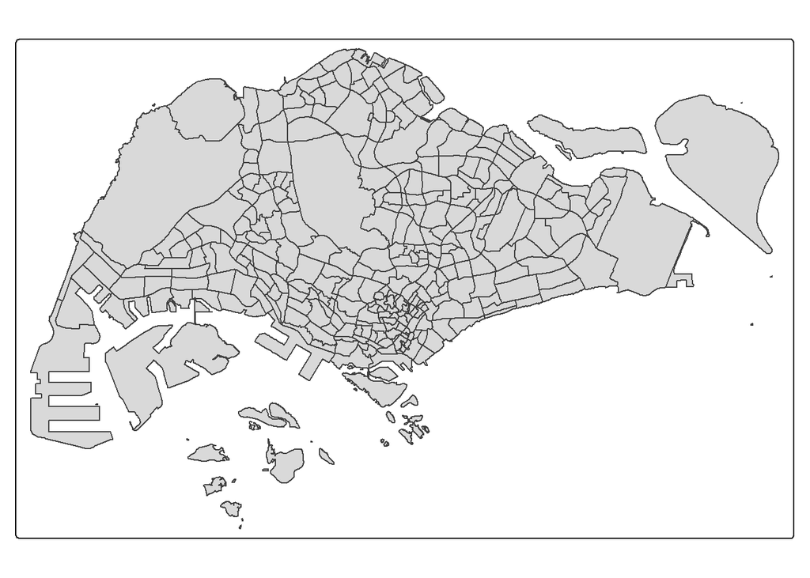

```r
tm_shape(mpsz_pop2020) +
  tm_polygons()
```

**(c) using tm_polygons()**

To draw a choropleth map showing the geographical distribution of a selected variable by planning subzone, the target variable such as *Dependency* needs to be assigned to *tm_polygons()*.

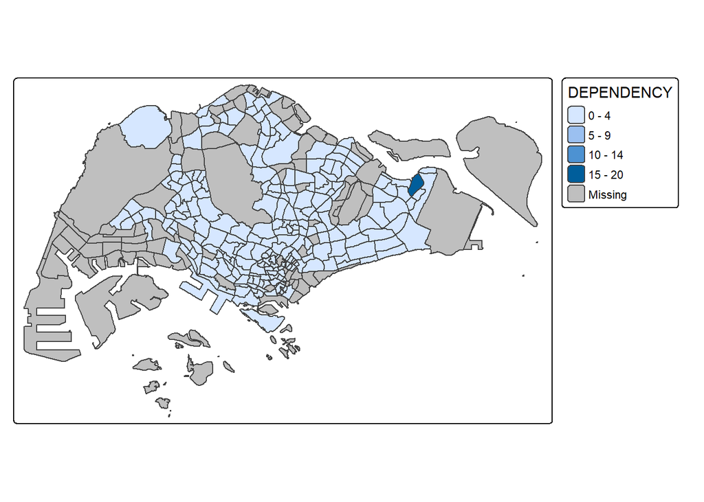

```r
tm_shape(mpsz_pop2020)+
  tm_polygons("DEPENDENCY")
```

**Note**

**(d) using tm_fill() and tm_border()**

*tm_polygons()* is a wraper of *tm_fill()* and *tm_border()*. *tm_fill()* shades the polygons by using the default colour scheme and *tm_borders()* adds the borders of the shapefile onto the choropleth map.

#### tm_fill()

The code chunk below draws a choropleth map by using *tm_fill()* alone. Note that the planning subzones are shared according to the respective dependecy values.

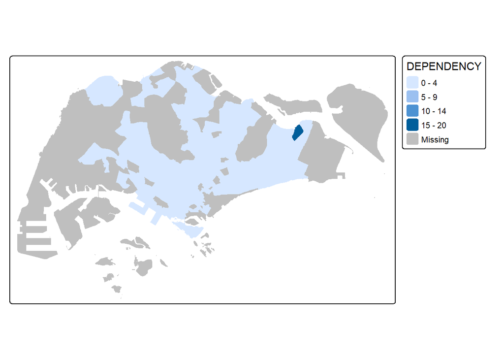

```r
tm_shape(mpsz_pop2020)+
  tm_fill("DEPENDENCY")
```

#### tm_borders()

tm_borders will be used to add the boundary of the planning subzones.

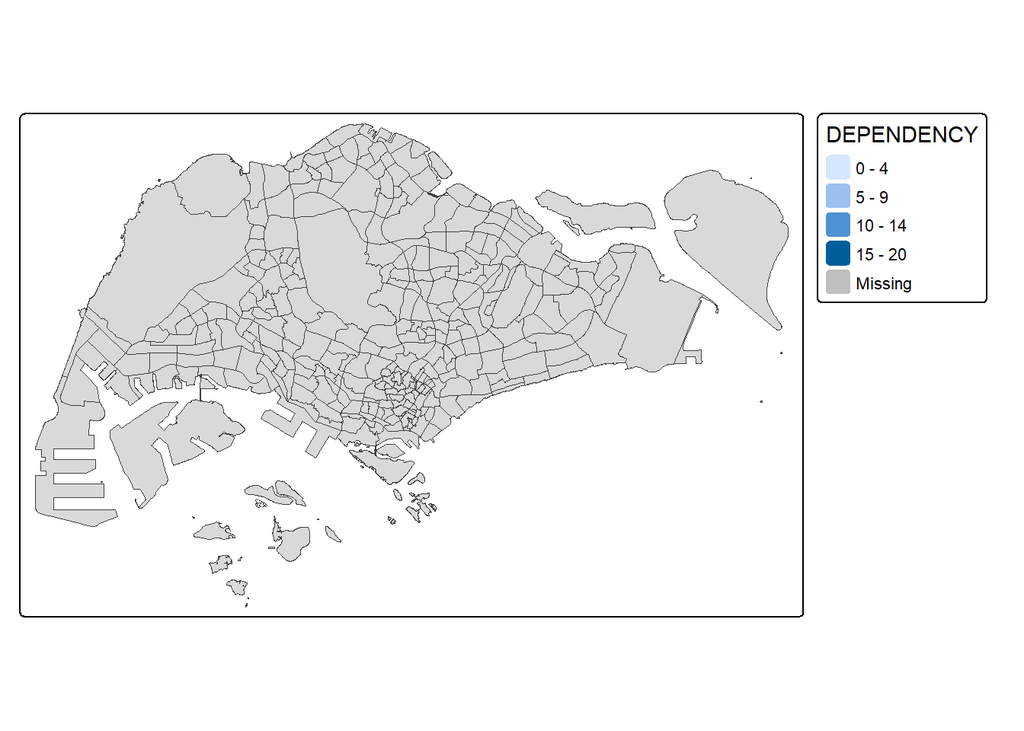

```r
tm_shape(mpsz_pop2020)+
  tm_fill("DEPENDENCY") +
  tm_borders(lwd = 0.1,  alpha = 1)
```

**(e) using tmap’s elements**

To draw a high quality and highly customisable cartographic choropleth map, **tmap**’s drawing elements should be used.

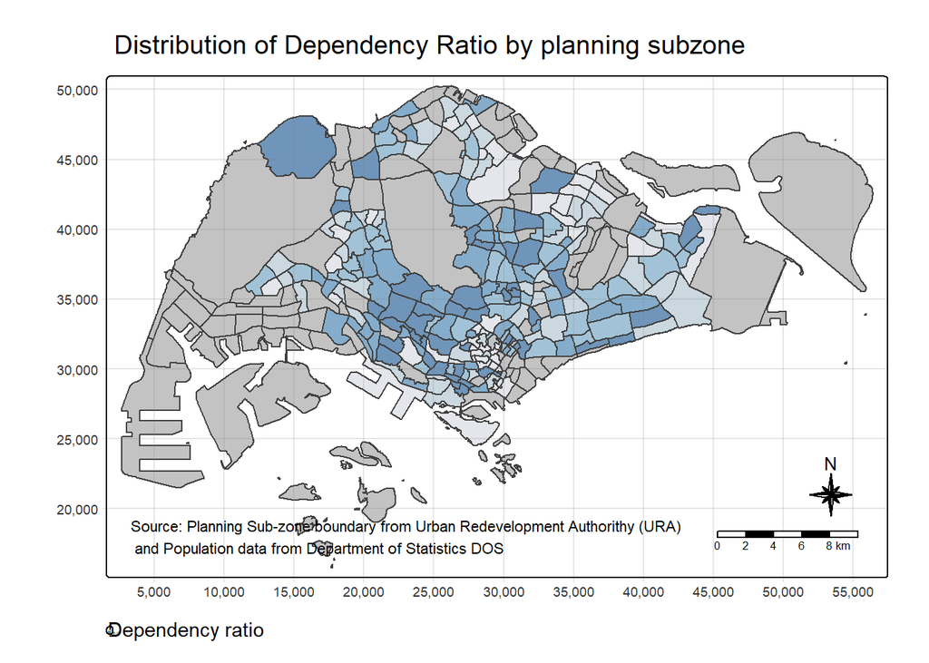

```r
tm_shape(mpsz_pop2020)+
  tm_fill("DEPENDENCY",
          style = "quantile",
          palette = "Blues",
          title = "Dependency ratio") +
  tm_layout(main.title = "Distribution of Dependency Ratio by planning subzone",
            main.title.position = "center",
            main.title.size = 1.2,
            legend.height = 0.45,
            legend.width = 0.35,
            frame = TRUE) +
  tm_borders(alpha = 0.5) +
  tm_compass(type="8star", size = 2) +
  tm_scalebar() +
  tm_grid(alpha =0.2) +
  tm_credits("Source: Planning Sub-zone boundary from Urban Redevelopment Authorithy (URA)\n and Population data from Department of Statistics DOS",
             position = c("left", "bottom"))
```

**Note**

Note that light-gray border lines have been added to the choropleth map.

The *alpha* argument is used to define transparency number between 0 (totally transparent) and 1 (not transparent). By default, the alpha value is 1.

Besides *alpha* argument, there are three other arguments for *tm_borders()*:

- *col* = border colour,
- *lwd* = border line width. The default is 1, and
- *lty* = border line type. The default is “solid”.

## 3 **Data classification methods of tmap**

Most choropleth maps employ some methods of data classification to take a large number of observations and group them into data ranges or classes.

**tmap** provides a ten data classification methods, namely: *fixed*, *sd*, *equal*, *pretty* (default), *quantile*, *kmeans*, *hclust*, *bclust*, *fisher*, and *jenks*.

To define a data classification method, the *style* argument of *tm_fill()* or *tm_polygons()* is used.

**(a) style**

**(i) jenks style**

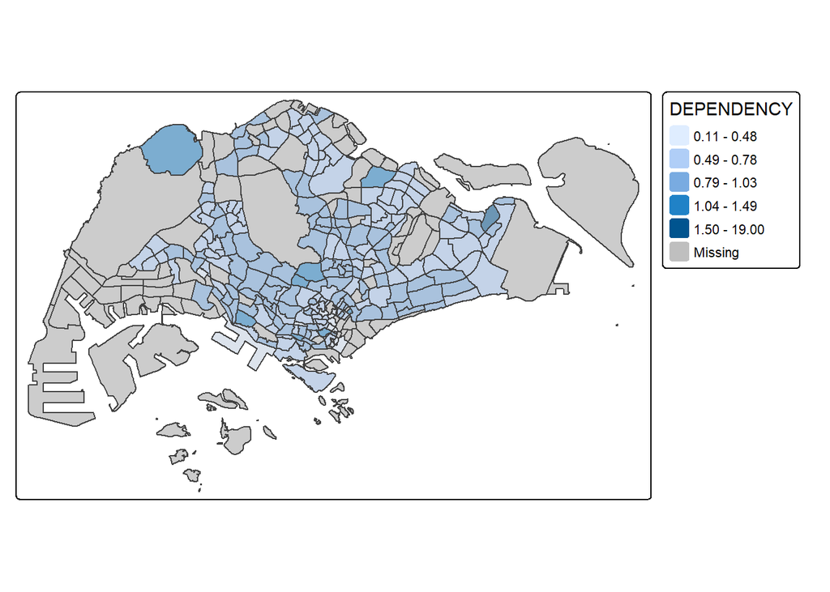

```r
tm_shape(mpsz_pop2020)+
  tm_fill("DEPENDENCY",
          n = 5,
          style = "jenks") +
  tm_borders(alpha = 0.5)
```

**(ii) equal style**

In the code chunk below, the *equal* data classification method is used.

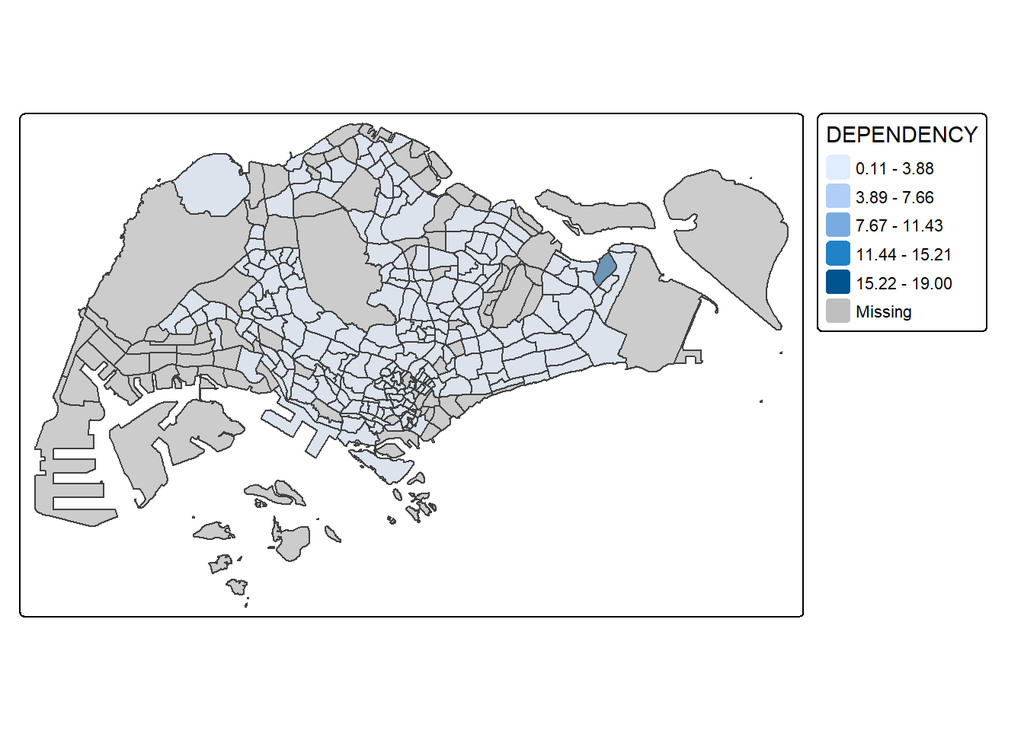

```r
tm_shape(mpsz_pop2020)+
  tm_fill("DEPENDENCY",
          n = 5,
          style = "equal") +
  tm_borders(alpha = 0.5)
```

**Note**

**(b) breaks**

For all built-in styles, category breaks are computed internally. To override these defaults, the breakpoints can be set explicitly using the *breaks* argument to the *tm_fill()*.

Note: **tmap** breaks include a minimum and maximum. Thus, to end up with n categories, n+1 elements must be specified in the *breaks* option (the values must be in increasing order).

Code chunk below will be used to compute and display the descriptive statistics of **DEPENDENCY** field in order to get descriptive statistics on the variable to aid setting break points.

```r
summary(mpsz_pop2020$DEPENDENCY)
```

```
   Min. 1st Qu.  Median    Mean 3rd Qu.    Max.    NA's
 0.1111  0.7147  0.7867  0.8585  0.8763 19.0000      92
```

The choropleth map is plotted with the above values by the code chunk below.

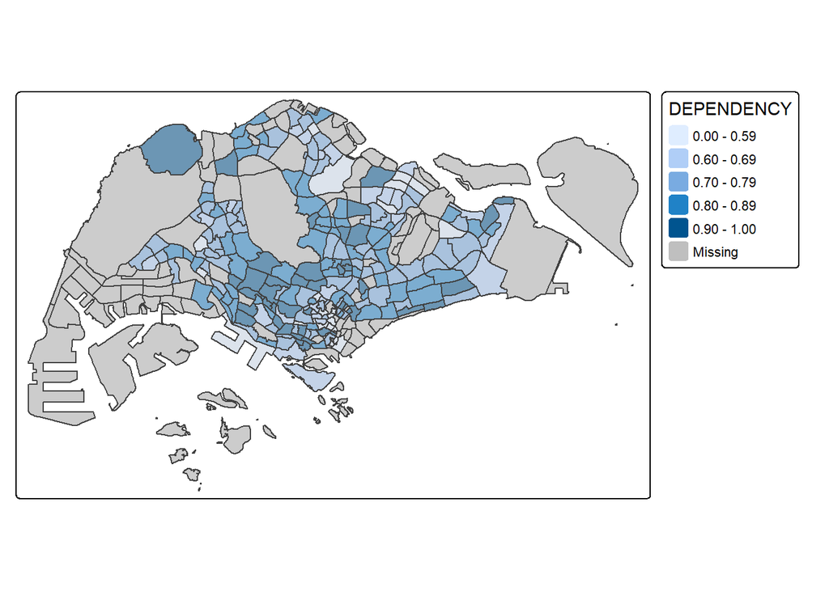

```r
tm_shape(mpsz_pop2020)+
  tm_fill("DEPENDENCY",
          breaks = c(0, 0.60, 0.70, 0.80, 0.90, 1.00)) +
  tm_borders(alpha = 0.5)
```

**(c) colour**

**tmap** supports colour ramps either defined by the user or a set of predefined colour ramps from the **RColorBrewer** package.

#### palette argument

To change the colour, assign the preferred colour to *palette* argument of *tm_fill()*

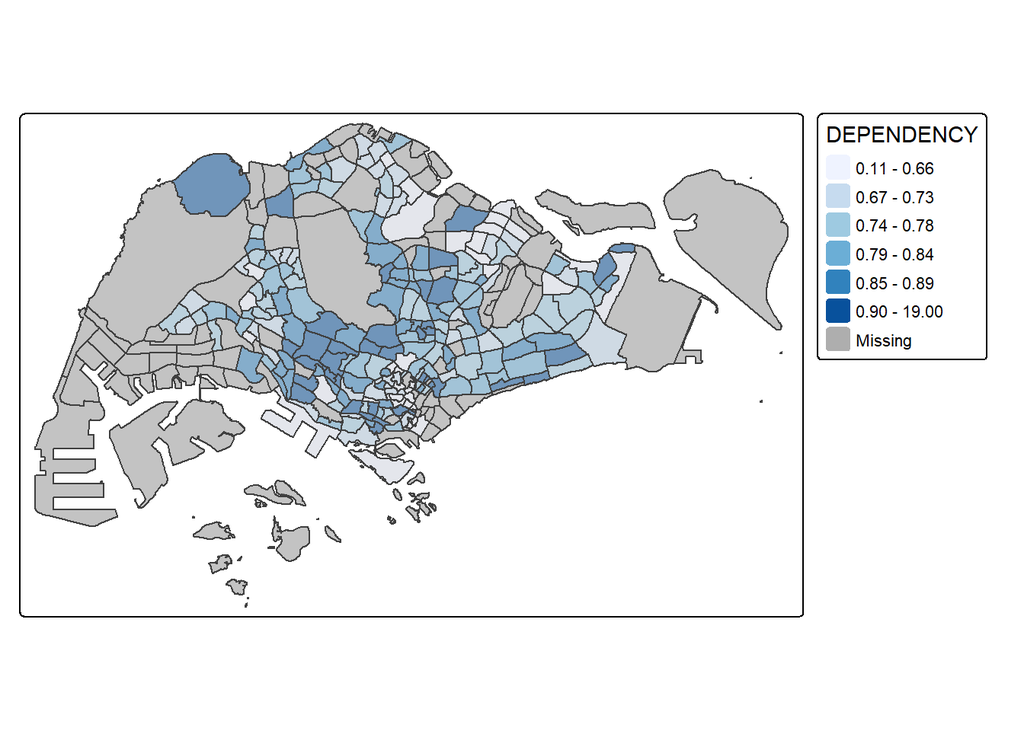

```r
tm_shape(mpsz_pop2020)+
  tm_fill("DEPENDENCY",
          n = 6,
          style = "quantile",
          palette = "Blues") +
  tm_borders(alpha = 0.5)
```

#### reverse color shading

To reverse the colour shading, add a “-” prefix.

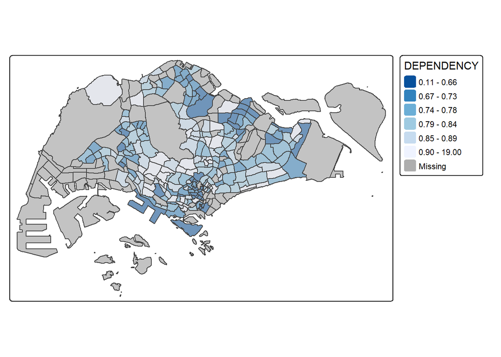

```r
tm_shape(mpsz_pop2020)+
  tm_fill("DEPENDENCY",
          n = 6,
          style = "quantile",
          palette = "-Blues") +
  tm_borders(alpha = 0.5)
```

**(d) layouts**

Map layout refers to the combination of all map elements into a cohensive map. Map elements includes: objects to be mapped, title, scale bar, compass, margins and aspects ratios. Colour settings and data classification methods covered in the previous section relate to the palette and break-points are used to affect how the map looks.

#### Map Legend

In **tmap**, several *legend* options are provided to change the placement, format and appearance of the legend.

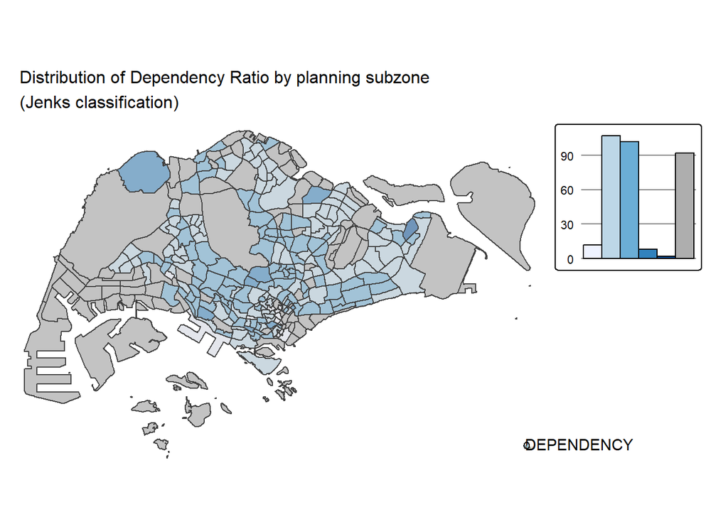

```r
tm_shape(mpsz_pop2020)+
  tm_fill("DEPENDENCY",
          style = "jenks",
          palette = "Blues",
          legend.hist = TRUE,
          legend.is.portrait = TRUE,
          legend.hist.z = 0.1) +
  tm_layout(main.title = "Distribution of Dependency Ratio by planning subzone \n(Jenks classification)",
            main.title.position = "center",
            main.title.size = 1,
            legend.height = 0.45,
            legend.width = 0.35,
            legend.outside = FALSE,
            legend.position = c("right", "bottom"),
            frame = FALSE) +
  tm_borders(alpha = 0.5)
```

**(e) style**

**tmap** allows a wide variety of layout settings to be changed using *tmap_style()*.

The code chunk below shows the *classic* style.

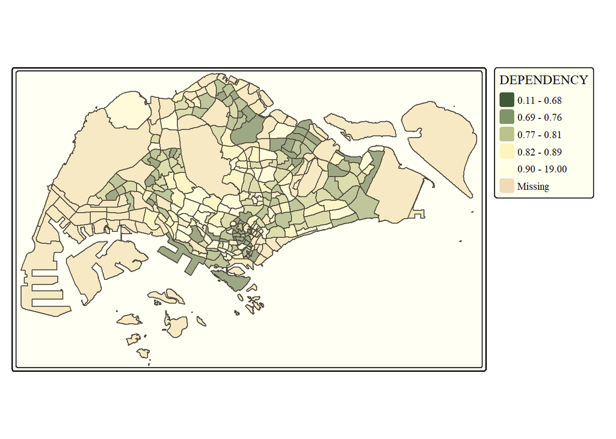

```r
tm_shape(mpsz_pop2020)+
  tm_fill("DEPENDENCY",
          style = "quantile",
          palette = "-Greens") +
  tm_borders(alpha = 0.5) +
  tmap_style("classic")
```

**(f) others**

Beside map style, **tmap** also also draws other map furniture e.g., compass, scale bar and grid lines.

In the code chunk below, *tm_compass()*, *tm_scalebar()* and *tm_grid()* are used to add compass, scale bar and grid lines onto the choropleth map.

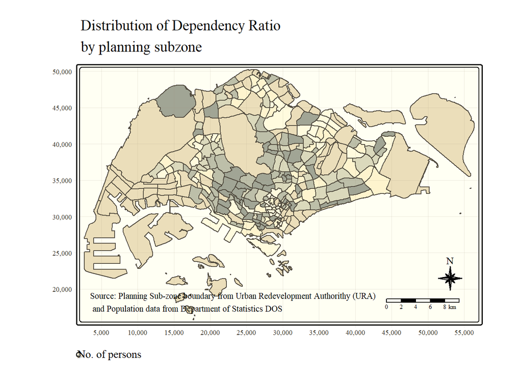

```r
tm_shape(mpsz_pop2020)+
  tm_fill("DEPENDENCY",
          style = "quantile",
          palette = "Blues",
          title = "No. of persons") +
  tm_layout(main.title = "Distribution of Dependency Ratio \nby planning subzone",
            main.title.position = "center",
            main.title.size = 1.2,
            legend.height = 0.45,
            legend.width = 0.35,
            frame = TRUE) +
  tm_borders(alpha = 0.5) +
  tm_compass(type="8star", size = 2) +
  tm_scalebar() +
  tm_grid(lwd = 0.1, alpha = 0.2) +
  tm_credits("Source: Planning Sub-zone boundary from Urban Redevelopment Authorithy (URA)\n and Population data from Department of Statistics DOS",
             position = c("left", "bottom"))
```

To reset the default style

```r
tmap_style("white")
```

## 4 **Drawing Small Multiple Choropleth Maps**

**Small multiple maps**, aka **facet maps**, are composed of many maps arranged side-by-side, and/or stacked vertically. Small multiple maps enable the visualisation of how spatial relationships change with respect to another variable, e.g. time.

In **tmap**, small multiple maps can be plotted in three ways:

- by assigning multiple values to at least one of the asthetic arguments
- by defining a group-by variable in *tm_facets()*
- by creating multiple stand-alone maps with *tmap_arrange()*.

**(a) aesthetic args**

**(i) tm_fill()**

Small multiple choropleth maps are created by defining *ncols* in **tm_fill()**

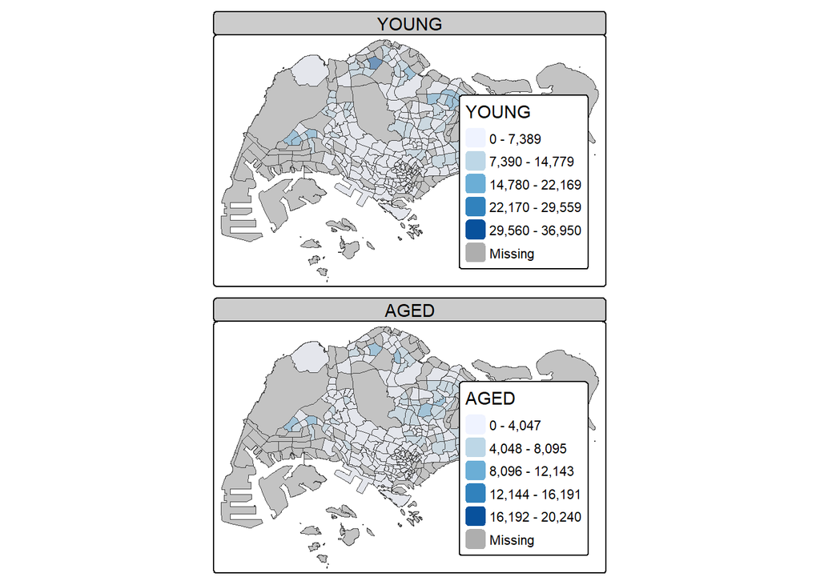

```r
tm_shape(mpsz_pop2020)+
  tm_fill(c("YOUNG", "AGED"),
          style = "equal",
          palette = "Blues") +
  tm_layout(legend.position = c("right", "bottom")) +
  tm_borders(alpha = 0.5) +
  tmap_style("white")
```

**(ii) tm_polygons()**

We can also facet the chart using tm_polygons().

[figure not shown]

```r
tm_shape(mpsz_pop2020)+
  tm_polygons(c("DEPENDENCY","AGED"),
          style = c("equal", "quantile"),
          palette = list("Blues","Greens")) +
  tm_layout(legend.position = c("right", "bottom"))
```

**(b) tm_facets()**

multiple small choropleth maps are created by using **tm_facets()**.

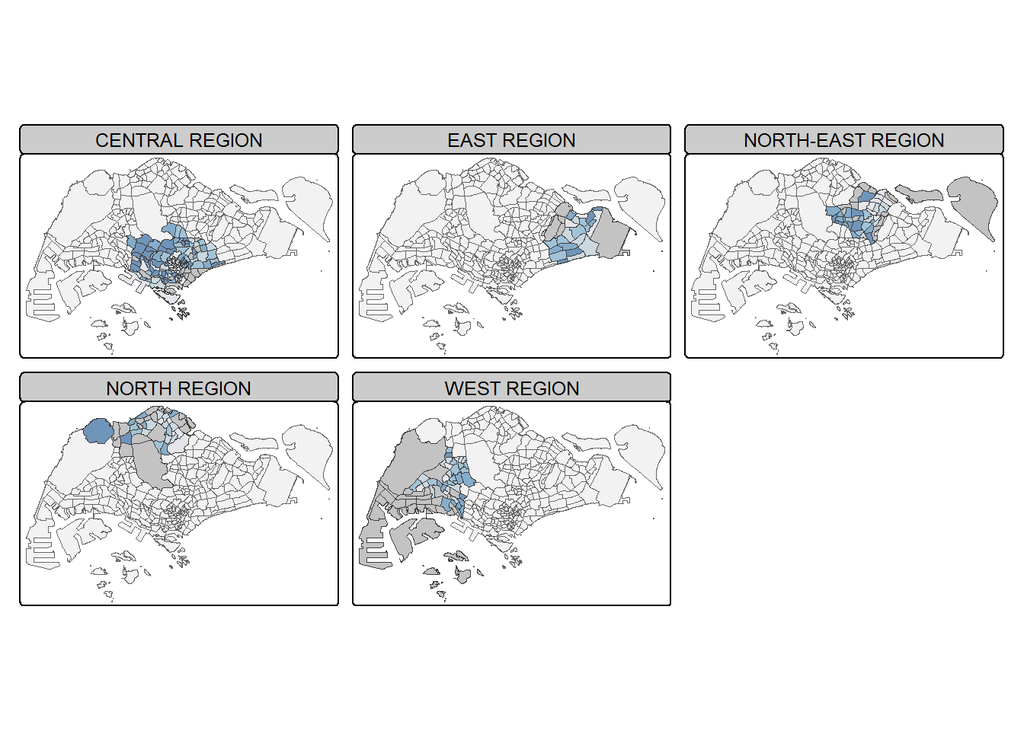

```r
tm_shape(mpsz_pop2020) +
  tm_fill("DEPENDENCY",
          style = "quantile",
          palette = "Blues",
          thres.poly = 0) +
  tm_facets(by="REGION_N",
            free.coords=TRUE,
            drop.shapes=FALSE) +
  tm_layout(legend.show = FALSE,
            title.position = c("center", "center"),
            title.size = 20) +
  tm_borders(alpha = 0.5)
```

**(c) map_arrange()**

multiple small choropleth maps are created by creating multiple stand-alone maps with **tmap_arrange()**.

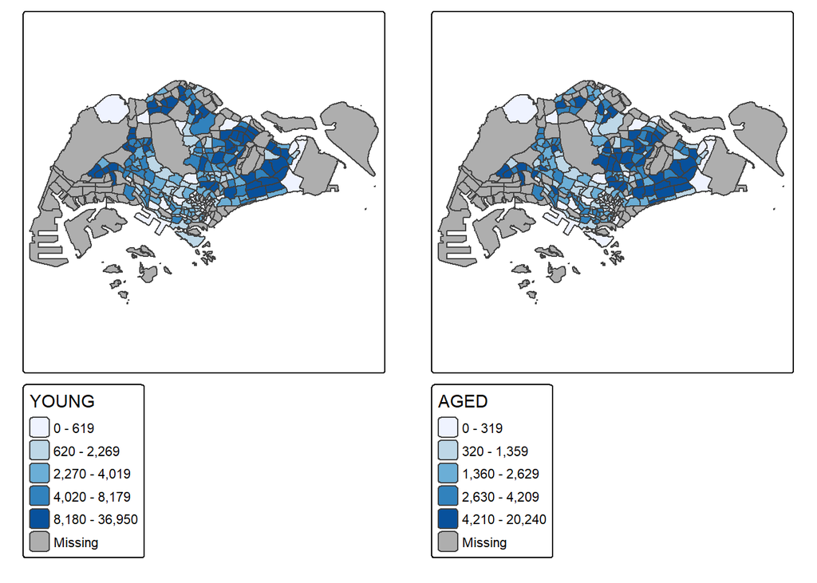

```r
youngmap <- tm_shape(mpsz_pop2020)+
  tm_polygons("YOUNG",
              style = "quantile",
              palette = "Blues")

agedmap <- tm_shape(mpsz_pop2020)+
  tm_polygons("AGED",
              style = "quantile",
              palette = "Blues")

tmap_arrange(youngmap, agedmap, asp=1, ncol=2)
```

## 5 **Mapping Spatial Object Meeting a Selection Criterion**

Use selection funtion to map spatial objects meeting the selection criterion.

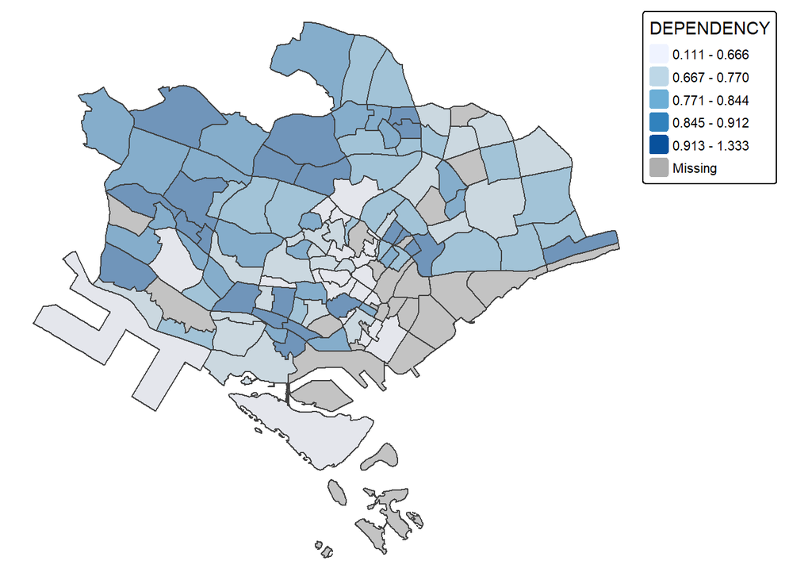

```r
tm_shape(mpsz_pop2020[mpsz_pop2020$REGION_N=="CENTRAL REGION", ])+
  tm_fill("DEPENDENCY",
          style = "quantile",
          palette = "Blues") +
  tm_layout(legend.outside = TRUE,
            legend.outside.position = "right",
            frame = FALSE) +
  tm_borders(alpha = 0.5)
```

## 6 References

### All about tmap package

- [tmap: Thematic Maps in R](https://www.jstatsoft.org/article/view/v084i06)
- [tmap](https://cran.r-project.org/web/packages/tmap/index.html)

### Geospatial data wrangling

- [sf: Simple Features for R](https://cran.r-project.org/web/packages/sf/index.html)
- [Simple Features for R: StandardizedSupport for Spatial Vector Data](https://journal.r-project.org/articles/RJ-2018-009/RJ-2018-009.pdf)
- [Reading, Writing and Converting Simple Features](https://cran.r-project.org/web/packages/sf/vignettes/sf2.html)